# Part II - Exploration of Trips Dataset

## by Emmanuel Gyan Ghanney

## (Visualization 1)

> This is a visualisation of start station names versus the number of times they were used.

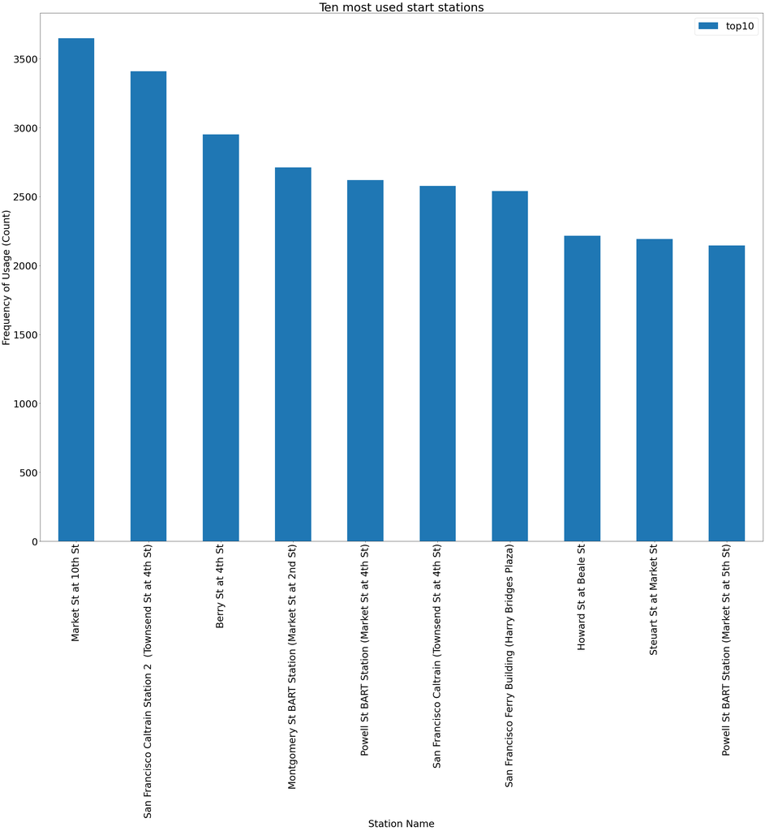

## Reasons and Outcomes

> This is relevant because it allows the firm to know which of their offices or stations are recieving the most orders. It can be conbined with day data to anticipate traffic.

> From the visualization it was evident that Market St at 10th St was had the most start trips

## (Visualization 2)

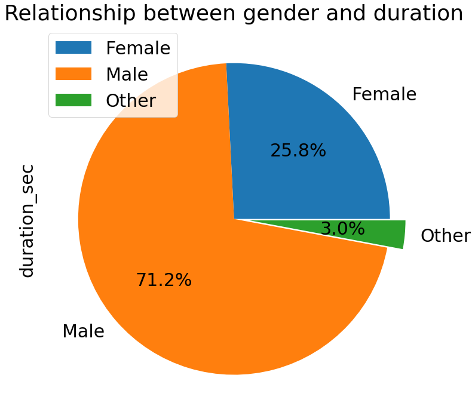

## Reason and Outcomes

> The visualisation was important because it help the business to understand who petronizing them most in terms of gender. It could also be used by marketing to implement marketing campagnes

> It was observed that there were more males than any other gender.

## (Visualization 3)

> This is a visualisation that represent the distribution and relationship of member birth year, duration in hours and how it is influenced by bike share trips

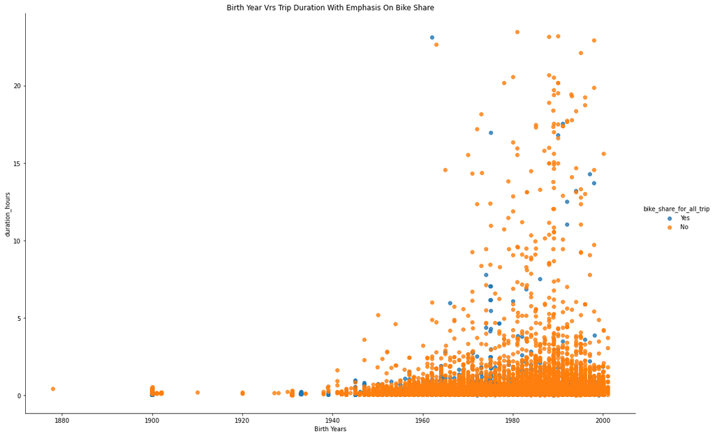

## Reason and Outcome

> This visualization is very important because it helps in bringing to light the how the clients are distributed in terms of whether they were shared trip or not.